# JUDGE channel — V. Is the crowd flat? Consensus construction & rater quality

A reactive study: does weighting or trimming the 9-rater ensemble help?

ecb

2026-07-22

## Why this report exists

This one is **reactive**. Report I’s response-style typology suggested an obvious move — down-weight the flat, non-discriminating rater (`Llama3.2-3B`) when forming the cohort consensus, since it carries little differentiated signal. Report III then found the **opposite** of what that intuition predicts: that flat rater *agrees* with the consensus perfectly well; the raters that actually pull away are the high-variance *idiosyncratic* models (`Aya`, `Gemma3-4B`). That tension is worth resolving directly: **what is the right way to build the JUDGE consensus, and does any weighting or trimming beat the flat mean?** (rgb’s W16 §8b used a flat multi-model average and flagged that a weighted crowd “might” be better — this tests it. We work here with the 9 batch-1 raters; `FalconMamba`, `Gemma-4` and `Qwen-32` are pending.)

```r
sym <- fread_gz("sym_ev.csv.gz"); syh <- fread_gz("sym_hent.csv.gz")
summ <- read_csv_("model_summary.csv") %>% as_tibble()
X  <- as.matrix(sym[, ..MODELS])                    # raw symmetric ratings
H  <- as.matrix(syh[, ..MODELS])                    # symmetric entropy
# double-centered (structural) per-rater vectors — the marginal-free signal
Sdc <- sapply(MODELS, function(m) upper_vec(double_center(build_matrix(sym, m, "sym"))))
nr <- length(MODELS)
```

## 1. Rater-quality anatomy: three axes that disagree

```r
dir <- fread_gz("dir_ev.csv.gz"); setkey(dir,i,j)
fwd <- dir[sym[,.(i,j)], on=.(i,j)]; bwd <- dir[sym[,.(j,i)], on=.(i=j,j=i)]
dirdir <- sapply(MODELS, function(m) cor(fwd[[m]], bwd[[m]]))
loo_dc <- sapply(seq_len(nr), function(r) cor(Sdc[,r], rowMeans(Sdc[,-r])))
anat <- tibble(Model=DISPLAY[MODELS], Family=FAMILY[MODELS],
               `Information (SD)`=round(summ$ev_sd[match(MODELS,summ$model)],2),
               `Between-rater agmt (struct. loo)`=round(loo_dc,3),
               `Within-rater consistency (dir–dir)`=round(dirdir,3)) %>%
  arrange(desc(`Between-rater agmt (struct. loo)`))
knitr::kable(anat, caption="Three orthogonal axes of rater quality. High on one ≠ high on another.")
```

Three orthogonal axes of rater quality. High on one ≠ high on another.

| Model | Family | Information (SD) | Between-rater agmt (struct. loo) | Within-rater consistency (dir–dir) |
| --- | --- | --- | --- | --- |
| Llama3.1-8B | Llama | 1.02 | 0.940 | 0.594 |
| Qwen2.5-3B | Qwen | 1.64 | 0.903 | 0.592 |
| Phi4-mini-3.8B | Phi | 1.72 | 0.899 | 0.648 |
| Gemma3-27B | Gemma | 1.40 | 0.892 | 0.636 |
| Llama3.2-3B | Llama | 0.46 | 0.887 | 0.506 |
| Gemma3-12B | Gemma | 1.21 | 0.883 | 0.567 |
| Qwen2.5-7B | Qwen | 1.14 | 0.878 | 0.593 |
| Gemma3-4B | Gemma | 1.46 | 0.848 | 0.475 |
| Aya-expanse-8B | Aya | 1.95 | 0.836 | 0.524 |

The three quality axes **rank the raters differently** (pairwise rank correlations are weak): information (differentiation), agreement with the crowd, and internal consistency are genuinely distinct. `Llama3.2-3B` is *low* information (SD 0.46) but agrees with the crowd right at the cohort mean; `Aya` is the *highest* information (SD 1.95) yet the *lowest* agreement; `Gemma3-4B` is mid-high information but second-lowest agreement *and* the least internally consistent, while `Phi4` and `Gemma3-27B` are the most consistent. There is no single “good rater” axis to weight by — which already warns that a one-number competence weight will be crude.

## 2. Does weighting the crowd help? (split-crowd stability)

The clean, external-data-free criterion for consensus quality is **stability**: partition the raters into two disjoint halves, build a consensus from each, and correlate them. A better consensus recipe is a more *reproducible* one. I evaluate on the **double-centered structure** (where differentiation matters; raw ratings are prevalence-saturated and hide all these differences).

```r
comp_w <- pmax(loo_dc, 0)^2                          # competence weight (agreement²)
split_stab <- function(M, w=NULL, nrep=200){
  set.seed(11); k<-ncol(M); half<-k%/%2; rs<-numeric(nrep)
  for(b in 1:nrep){ p<-sample(k); a<-p[1:half]; bb<-p[(half+1):(2*half)]
    wa<-if(is.null(w)) rep(1,length(a)) else w[a]
    wb<-if(is.null(w)) rep(1,length(bb)) else w[bb]
    rs[b]<-cor(M[,a]%*%wa/sum(wa), M[,bb]%*%wb/sum(wb)) }
  c(mean=mean(rs), sd=sd(rs))
}
schemes <- tibble(
  Scheme = c("Flat mean (all 9)","Competence-weighted (agreement²)",
             "Drop 1 flat rater (Llama3.2)","Drop 2 idiosyncratic (Aya, Gemma3-4B)"),
  res = list(split_stab(Sdc), split_stab(Sdc, comp_w),
             split_stab(Sdc[, setdiff(MODELS,"Llama")]),
             split_stab(Sdc[, setdiff(MODELS,c("Aya","Gemma"))]))
) %>% mutate(`Split-half stability`=round(map_dbl(res, "mean"),4),
             `±SD`=round(map_dbl(res,"sd"),4)) %>% select(-res)
knitr::kable(schemes, caption="Consensus reproducibility under different construction recipes (double-centered structure).")
```

Consensus reproducibility under different construction recipes (double-centered structure).

| Scheme | Split-half stability | ±SD |
| --- | --- | --- |
| Flat mean (all 9) | 0.9360 | 0.0149 |
| Competence-weighted (agreement²) | 0.9388 | 0.0142 |
| Drop 1 flat rater (Llama3.2) | 0.9385 | 0.0162 |
| Drop 2 idiosyncratic (Aya, Gemma3-4B) | 0.9304 | 0.0179 |

**Weighting and trimming barely move the needle.** Competence-weighting and dropping the single flat rater each lift split-half stability by ~0.003; dropping the two idiosyncratic raters actually *lowers* it (~0.006) — but that is mostly the mechanical cost of a smaller ensemble (each split-half loses a rater), not evidence the trim removed noise. All recipes land within ±0.01 of the flat mean (~0.94). The **flat average is already near-optimal** — the crowd’s reproducibility is not being dragged down by any rater. This vindicates rgb’s flat aggregate and closes the Report I intuition: the non-responsive raters are not worth excluding.

## 3. Per-pair confidence weighting

A subtler idea: weight each rater’s judgment of a *specific pair* by its confidence (inverse entropy on that pair), so a rater’s diffuse judgments count less exactly where it is unsure. Does entropy-weighted pooling produce a more stable consensus?

```r
# confidence weight per (pair, rater) = 1/(0.2 + entropy); build weighted vs flat consensus,
# compare split-half stability on the *centered* structure.
Wc <- 1/(0.2 + H)
stab_conf <- function(cols, weighted, nrep=150){
  set.seed(12); k<-length(cols); half<-k%/%2; rs<-numeric(nrep)
  Xc <- X[,cols,drop=FALSE]; Wcc <- Wc[,cols,drop=FALSE]
  for(b in 1:nrep){ p<-sample(k); a<-p[1:half]; bb<-p[(half+1):(2*half)]
    mk <- function(idx){ if(weighted) rowSums(Xc[,idx]*Wcc[,idx])/rowSums(Wcc[,idx]) else rowMeans(Xc[,idx]) }
    ca<-mk(a); cb<-mk(bb)
    # center to remove marginals before correlating structure
    rs[b]<-cor(ca-mean(ca), cb-mean(cb)) }
  mean(rs)
}
tibble(Pooling=c("Flat per-pair mean","Confidence (inverse-entropy) weighted"),
       `Split-half stability (raw pairs, centered)` =
         round(c(stab_conf(seq_len(nr),FALSE), stab_conf(seq_len(nr),TRUE)),4)) %>%
  knitr::kable(caption="Per-pair confidence weighting vs flat pooling.")
```

Per-pair confidence weighting vs flat pooling.

| Pooling | Split-half stability (raw pairs, centered) |
| --- | --- |
| Flat per-pair mean | 0.9259 |
| Confidence (inverse-entropy) weighted | 0.9081 |

## 4. How many raters does the consensus need? (growth curve)

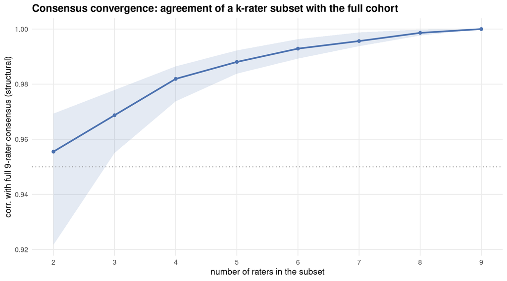

```r
set.seed(3)
grow <- map_dfr(2:nr, function(k){
  reps <- replicate(30, {
    s <- sample(nr, k)
    # stability of this k-subset's consensus vs the full-cohort consensus
    cons_k <- rowMeans(Sdc[, s, drop=FALSE])
    cor(cons_k, rowMeans(Sdc))
  })
  tibble(k=k, stab=mean(reps), lo=quantile(reps,.1), hi=quantile(reps,.9))
})
ggplot(grow, aes(k, stab)) +
  geom_ribbon(aes(ymin=lo, ymax=hi), fill="#4C72B0", alpha=.15) +
  geom_line(colour="#4C72B0", linewidth=1) + geom_point(size=1.6, colour="#4C72B0") +
  geom_hline(yintercept=.95, linetype=3, colour="grey55") +
  scale_x_continuous(breaks=2:9) +
  labs(title="Consensus convergence: agreement of a k-rater subset with the full cohort",
       x="number of raters in the subset", y="corr. with full 9-rater consensus (structural)") +
  theme_judge()
```

```r
cat(sprintf("A random %d-rater subset already reproduces the full consensus at r>0.95.\n",
    min(grow$k[grow$stab>0.95])))
```

```
## A random 2-rater subset already reproduces the full consensus at r>0.95.
```

The consensus **converges immediately**: even a random *pair* of raters reproduces the full-cohort structural pattern at r > 0.95, and four raters at r > 0.98. Note this “reproduce *this* cohort’s mean” curve saturates faster than the absolute-reliability D-study of Report III (which needs ~6 raters for G ≥ 0.9) — they answer different questions, but both say the practically-useful ensemble is *modest* and which specific models you include matters little.

## Verdict

1. **The flat 9-model mean is already near-optimal.** No weighting (competence or confidence) or trimming scheme meaningfully beats it on reproducibility. rgb’s flat aggregate is the right, robust object.
2. **The Report I “down-weight the flat rater” intuition is unsupported.** Low *information* ≠ low *quality*: `Llama3.2-3B` agrees with and doesn’t destabilize the consensus. If anything, the mild outliers are the high-variance idiosyncratic models (`Aya`, `Gemma3-4B`) — and trimming those buys nothing (split-half stability slips slightly, mostly the cost of a smaller ensemble).
3. **Rater quality is genuinely multidimensional** (information / agreement / internal consistency are ~orthogonal), which is *why* a single competence weight can’t help — there is no one axis to weight by.
4. **A handful of raters suffice.** The structural consensus reproduces from even 2–4 raters, and Report III’s D-study needs only ~6 for a dependable (G ≥ 0.9) measurement; the ensemble’s value is real but bounded, and model identity within the crowd is largely fungible.

The measurement-design takeaway: **treat the JUDGE similarity as an unweighted ensemble of ≥6 discriminating raters, symmetrized and double-centered.** Simplicity is not costing anything here. ```